# Monkfish Ismooth

### Uncalibrated Bigelow Data

StockEff also provides the Bigelow data directly, meaning not calibrated to Albatross units. These data can also be used in Ismooth. Since the biomass calibration in StockEff is constant, the expectation is that there will not be a difference between the calibrated and uncalibrated values when the same time period is used for the averaging (see section below). Numerical precision in the StockEff files means this does not exactly happen though, but it is close.

```r
mydata <- read.csv(file.path(monkpath, "STOCKEFF_SV_164499_NORTH_NONE_uncalibrated_indices.csv")) |>
  filter(YEAR >= 2009) |>
  rename(INDEX = INDEX_UNCALIBR)

northuncal <- clean_stockeff_survey_data(mydata, mypurpose, myseasons, myindextype, myfills_north)

nlastuncal <- wrapIsmooth(northuncal, 1964, lastyear, c("FILLED_SPRING", "FILLED_FALL_LAGGED"),
                  paste("North", lastyear, "Uncalibrated"))

mydata <- read.csv(file.path(monkpath, "STOCKEFF_SV_164499_SOUTH_NONE_uncalibrated_indices.csv")) |>
  filter(YEAR >= 2009) |>
  rename(INDEX = INDEX_UNCALIBR)

southuncal <- clean_stockeff_survey_data(mydata, mypurpose, myseasons, myindextype, myfills_south)

slastuncal <- wrapIsmooth(southuncal, 1964, lastyear, c("FILLED_SPRING", "FILLED_FALL_LAGGED"),
                  paste("South", lastyear, "Uncalibrated"))
```

**North**

**Multiplier Plot**

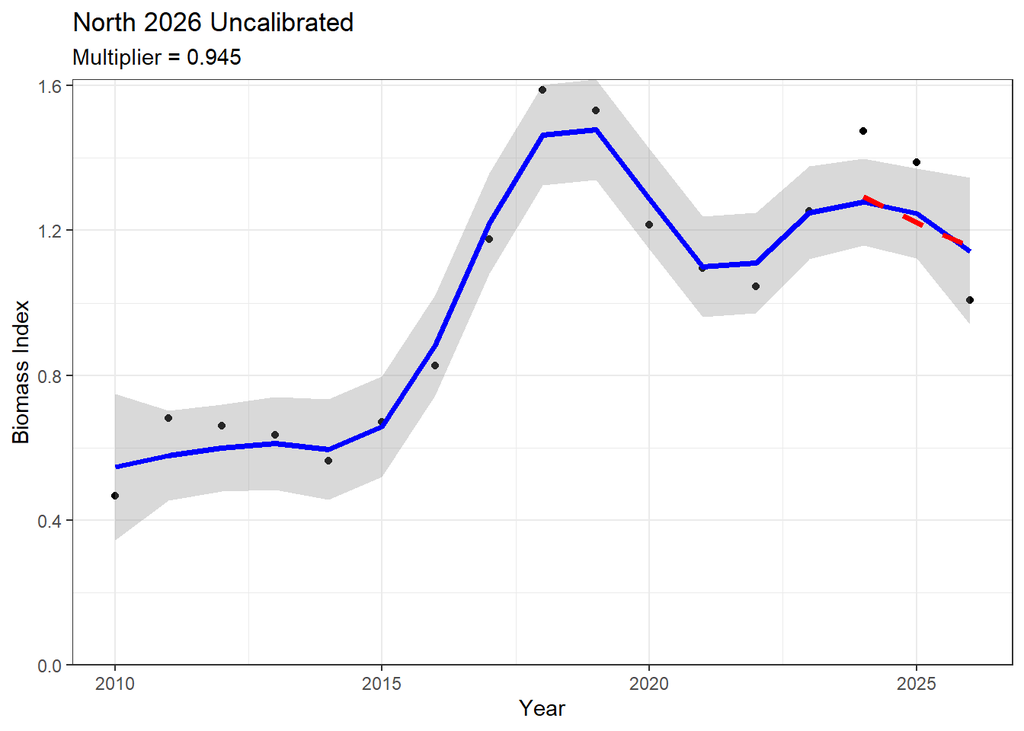

```r
print(nlastuncal$Ismooth$tsplot)
```

**Survey Average Plot**

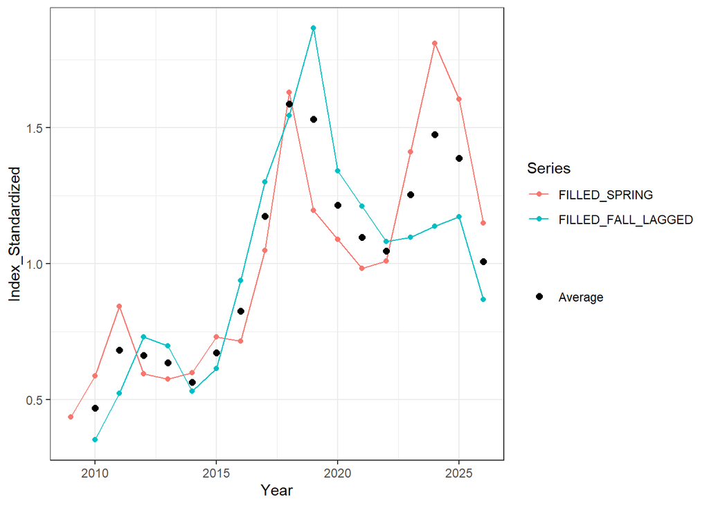

```r
print(nlastuncal$sap)
```

**6 Panel Plot**

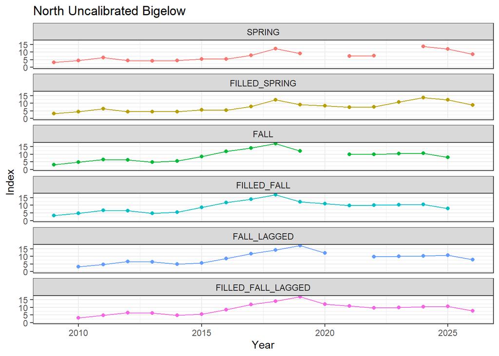

```r
plot_6_ts(northuncal, "North Uncalibrated Bigelow")
```

**South**

**Multiplier Plot**

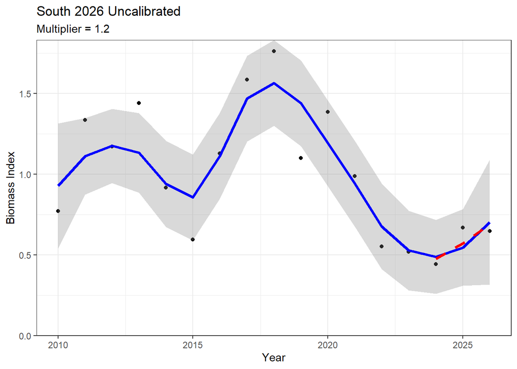

```r
print(slastuncal$Ismooth$tsplot)
```

**Survey Average Plot**

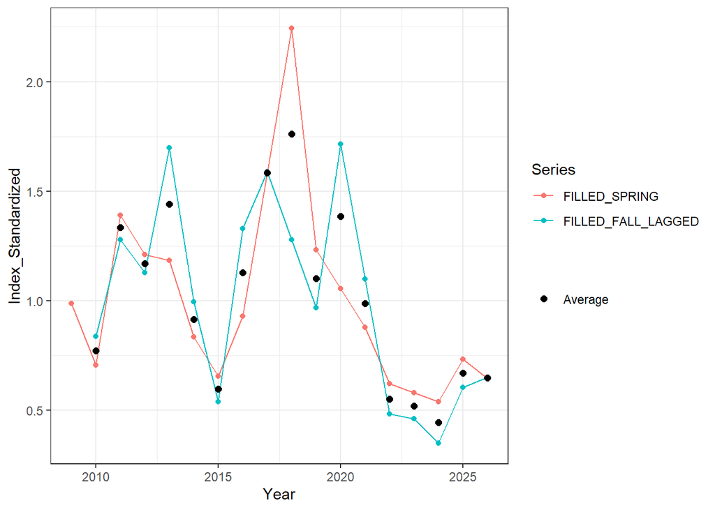

```r
print(slastuncal$sap)
```

**6 Panel Plot**

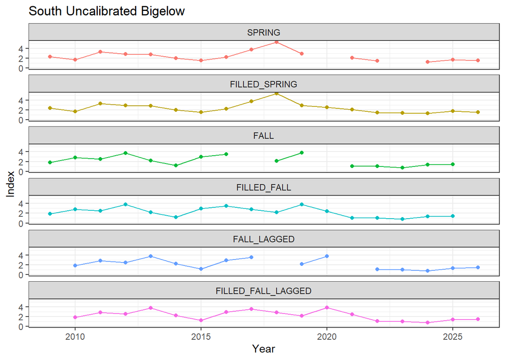

```r
plot_6_ts(southuncal, "South Uncalibrated Bigelow")
```

The table below compares four multipliers for each monkfish stock. The first row for each stock shows the original results from the standard workflow using the full time series for the surveys. The second row for each stock shows the result of using those same survey time series, but starting the series in 2009 before computing the average of the surveys. The third row shows the uncalibrated Bigelow using kg/tow units, which has the closest match to the calibrated time series starting in 2009 (the second row). Finally, the chainsweep expansion results are shown in the fourth row for each stock showing the impact of changes in the length distribution by year causing changes in the biomass in metric tons for each survey and thus the largest differences in multipliers.

```r
# compute the multipliers from the original data using 2009 as the start year
n2009last <- wrapIsmooth(north, 2009, lastyear, c("FILLED_SPRING", "FILLED_FALL_LAGGED"), paste("North 2009 -", lastyear))
s2009last <- wrapIsmooth(south, 2009, lastyear, c("FILLED_SPRING", "FILLED_FALL_LAGGED"), paste("South 2009 -", lastyear))

# expand this table to include Tim's values, full time series, limited time series, and uncal
compcal <- tibble(Stock = rep(c("North", "South"), each=4),
                  Treatment = "Filled",
                  Only_Bigelow_Years = rep(c("No", "Yes", "Yes", "Yes"), 2),
                  Calibrated_to_Alb = rep(c("Yes", "Yes", "No", "No"), 2),
                  Units = rep(c("kg/tow", "kg/tow", "kg/tow", "metric tons"), 2),
                  Multiplier = round(c(nlastfill$Ismooth$multiplier,
                                       n2009last$Ismooth$multiplier,
                                       nlastuncal$Ismooth$multiplier,
                                       nchainlast$Ismooth$multiplier,
                                       slastfill$Ismooth$multiplier,
                                       s2009last$Ismooth$multiplier,
                                       slastuncal$Ismooth$multiplier,
                                       schainlast$Ismooth$multiplier), 3))

knitr::kable(compcal)
```

| Stock | Treatment | Only_Bigelow_Years | Calibrated_to_Alb | Units | Multiplier |
| --- | --- | --- | --- | --- | --- |
| North | Filled | No | Yes | kg/tow | 0.944 |
| North | Filled | Yes | Yes | kg/tow | 0.945 |
| North | Filled | Yes | No | kg/tow | 0.945 |
| North | Filled | Yes | No | metric tons | 0.982 |
| South | Filled | No | Yes | kg/tow | 1.170 |
| South | Filled | Yes | Yes | kg/tow | 1.199 |
| South | Filled | Yes | No | kg/tow | 1.200 |
| South | Filled | Yes | No | metric tons | 1.238 |

## How to Add a Series Not in StockEff

Not all the series needed for a given assessment using Ismooth will be available in StockEff. For example, the NEFMC SSC approved the use of multiple catch per unit effort (CPUE) time series for both monkfish stocks. These will not be in StockEff, but rather produced using other code. It is easy to add such a time series to the Ismooth workflow. Simply create a tibble with columns Year, Series, and Index for the CPUE time series, rbind it to the existing tibble from StockEff, then select the correct series to send to the standardize and combine function.

The following code creates a dummy CPUE series for the northern monkfish stock to demonstrate how to include it in the workflow. The dummy CPUE series was intentionally created to have a much different trend than the bottom trawl surveys, but does not reflect any actual CPUE series for this stock. It is shown to demonstrate how stable the multiplier can be even when a much different time series is included. This is due to the dependence of the multiplier on the final three years and the use of the loess smoother. This will not always be the case though, sometimes the additional of a seemingly similar series will cause the multiplier to change dramatically. This can happen more often when there are missing surveys that treated as missing.

```r
CPUE_north <- tibble(Year = 2001:2026,
                     Series = "Dummy CPUE",
                     Index = (1:26) * exp(rnorm(26, 0, 0.1)))

cpue_plot <- ggplot(CPUE_north, aes(x=Year, y=Index)) +
  geom_point() +
  geom_line() +
  ggtitle("Dummy CPUE") +
  theme_bw() +
  expand_limits(y=0)

northplus <- rbind(north, CPUE_north)

YearStart <- 2001
YearEnd <- 2026
myseries <- c("FILLED_SPRING", "FILLED_FALL_LAGGED", "CPUE")

nlastCPUE <- wrapIsmooth(northplus, 2001, lastyear,
                 c("FILLED_SPRING", "FILLED_FALL_LAGGED", "Dummy CPUE"),
                 "North with Dummy CPUE")
```

**Multiplier Plot**

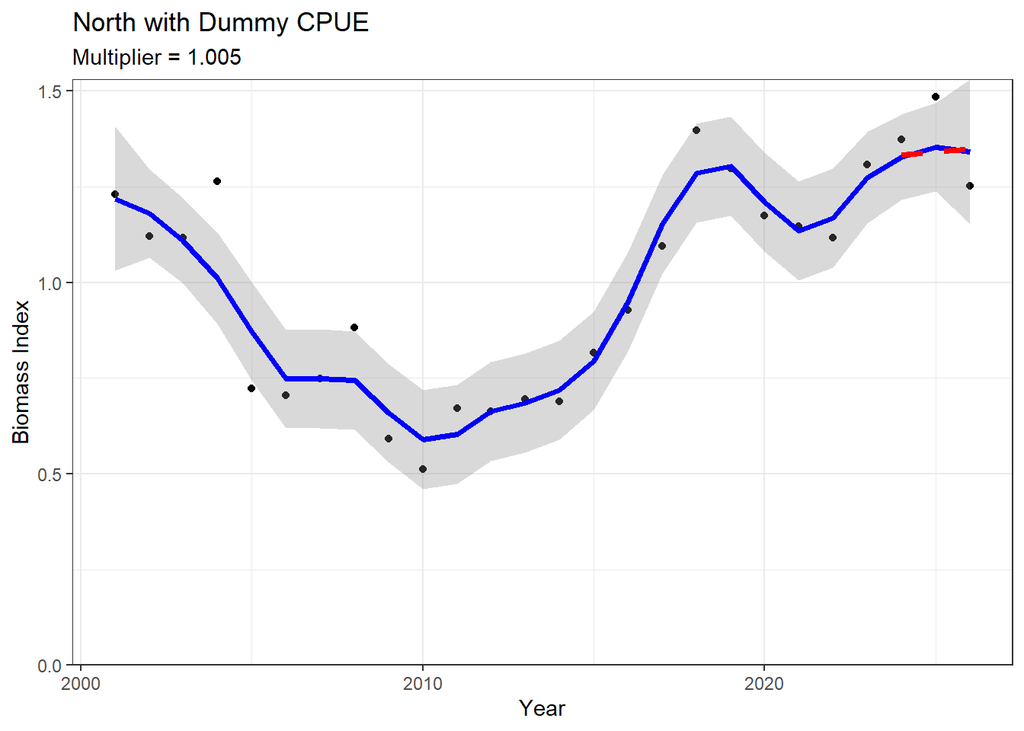

```r
print(nlastCPUE$Ismooth$tsplot)
```

**Survey Average Plot**

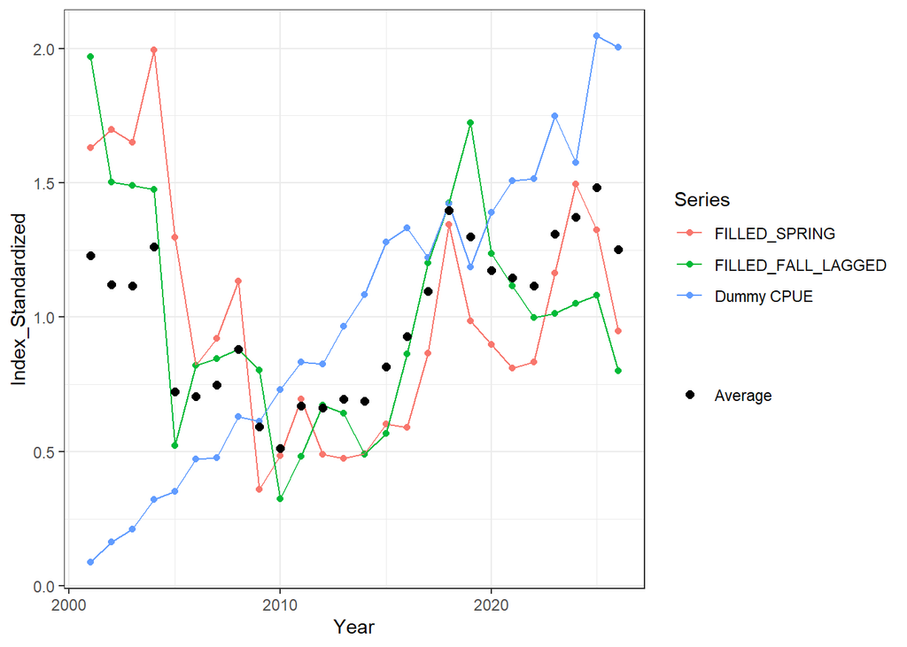

```r
print(nlastCPUE$sap)
```

**CPUE Plot**

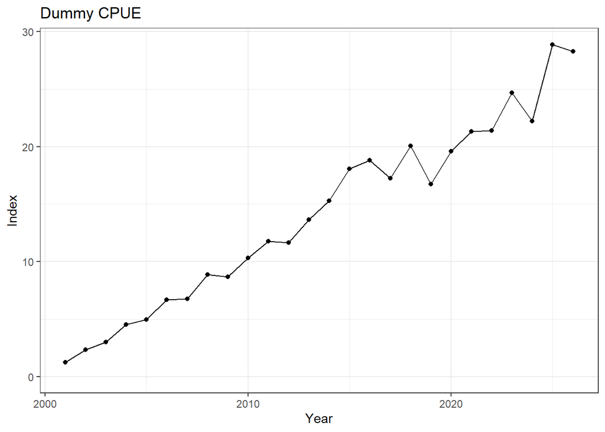

```r
print(cpue_plot)
```

## Time Period for Averages

A tricky aspect of Ismooth is how the averaging of the surveys occurs when different time periods are considered. As seen above, the Ismooth multiplier can change when the averaging across surveys is done for different time periods. This does not happen when a single average time series is used, as seen below in the Multiplier Plot where the Once line is constant across a large range of start and end years for both stocks (the only times the once line changes value, it does so at the third decimal place as a result of numerical rounding issues). In constrast, when the average is calculated for each combination of start and end year, there can be much larger (although still relatively small) changes in the Multiplier Plot (although this does not always happen, as seen in the bottom left panel). The reason for these different multiplier estimates can be seen in the Avg Plot and Loess Plot where the average value gets scaled a bit differently for each start and end year combination, causing the loess smooth to behave a bit differently at the end of the time series. The commented code in the section below can be uncommented to see how this works. This dependency of the average on the start and end year is why it is important to check how the average was calculated when trying to confirm previous Ismooth results, as well as whether missing surveys were filled or not.

```r
mylastyear <- c(2022, 2024, 2026)
nly <- length(mylastyear)
mystartyear <- seq(1965, 2010, 5) # c(1964, 1970, 1980, 1990, 2000, 2010)
nsy <- length(mystartyear)


for (j in 1:nly){
  north_once <- standardize_and_combine_indices(north, 1964, mylastyear[j],
                                                c("FILLED_SPRING", "FILLED_FALL_LAGGED"))
  south_once <- standardize_and_combine_indices(south, 1964, mylastyear[j],
                                                c("FILLED_SPRING", "FILLED_FALL_LAGGED"))
  for (i in 1:nsy){
    ncalc <- wrapIsmooth(north, mystartyear[i], mylastyear[j], c("FILLED_SPRING", "FILLED_FALL_LAGGED"), NULL)
    scalc <- wrapIsmooth(south, mystartyear[i], mylastyear[j], c("FILLED_SPRING", "FILLED_FALL_LAGGED"), NULL)

    noncedata <- north_once$avg |>
      filter(Year >= mystartyear[i])
    nonce <- ApplyPlanBsmooth(noncedata, my.title = NULL, showplots = FALSE)

    soncedata <- south_once$avg |>
      filter(Year >= mystartyear[i])
    sonce <- ApplyPlanBsmooth(soncedata, my.title = NULL, showplots = FALSE)

    thisdfn <- tibble(Stock = "North",
                      StartYear = mystartyear[i],
                      EndYear = paste("EndYear =", mylastyear[j]),
                      Calculated = round(ncalc$Ismooth$multiplier, 3),
                      Once = round(nonce$multiplier, 3))
    # pred24 = nonce$reg.use$pred[1], used to demonstrate the only change is in last year
    # pred25 = nonce$reg.use$pred[2],
    # pred26 = nonce$reg.use$pred[3])

    thisdfs <- tibble(Stock = "South",
                      StartYear = mystartyear[i],
                      EndYear = paste("EndYear =", mylastyear[j]),
                      Calculated = round(scalc$Ismooth$multiplier, 3),
                      Once = round(sonce$multiplier, 3))
    # pred24 = sonce$reg.use$pred[1], used to demonstrate the only change is in last year
    # pred25 = sonce$reg.use$pred[2],
    # pred26 = sonce$reg.use$pred[3])

    thisavgn <- tibble(Stock = "North",
                       StartYear = mystartyear[i],
                       EndYear = paste("EndYear =", mylastyear[j]),
                       Year = ncalc$Ismooth$dat.use$Year,
                       avg = ncalc$Ismooth$dat.use$avg,
                       loess = as.numeric(ncalc$Ismooth$pred_fit$fit))

    thisavgs <- tibble(Stock = "South",
                       StartYear = mystartyear[i],
                       EndYear = paste("EndYear =", mylastyear[j]),
                       Year = scalc$Ismooth$dat.use$Year,
                       avg = scalc$Ismooth$dat.use$avg,
                       loess = as.numeric(scalc$Ismooth$pred_fit$fit))

    if (i == 1 & j == 1){
      df <- rbind(thisdfn, thisdfs)
      avgdf <- rbind(thisavgn, thisavgs)
    } else {
      df <- rbind(df, thisdfn, thisdfs)
      avgdf <- rbind(avgdf, thisavgn, thisavgs)
    }
  }
}
dflong <- df |>
  arrange(Stock, StartYear) |>
  pivot_longer(cols = c(Calculated, Once), names_to = "How", values_to = "Multiplier")

tp1 <- ggplot(dflong, aes(x=StartYear, y=Multiplier, group=How, color=How)) +
  geom_point() +
  geom_line() +
  facet_wrap(EndYear~Stock, scales="free_y", ncol=2) +
  theme_bw()

avgdf <- avgdf |>
  filter(StartYear %in% c(1970, 1980, 1990, 2000, 2010)) |>
  mutate(StartYear = factor(StartYear))

tp2 <- ggplot(avgdf, aes(x=Year, y=avg, group=StartYear, color=StartYear)) +
  geom_point() +
  geom_line() +
  facet_wrap(EndYear~Stock, scales="free_y", ncol=2) +
  theme_bw()

tp3 <- ggplot(avgdf, aes(x=Year, y=loess, group=StartYear, color=StartYear)) +
  geom_point() +
  geom_line() +
  facet_wrap(EndYear~Stock, scales="free_y", ncol=2) +
  theme_bw()
```

**Multiplier Plot**

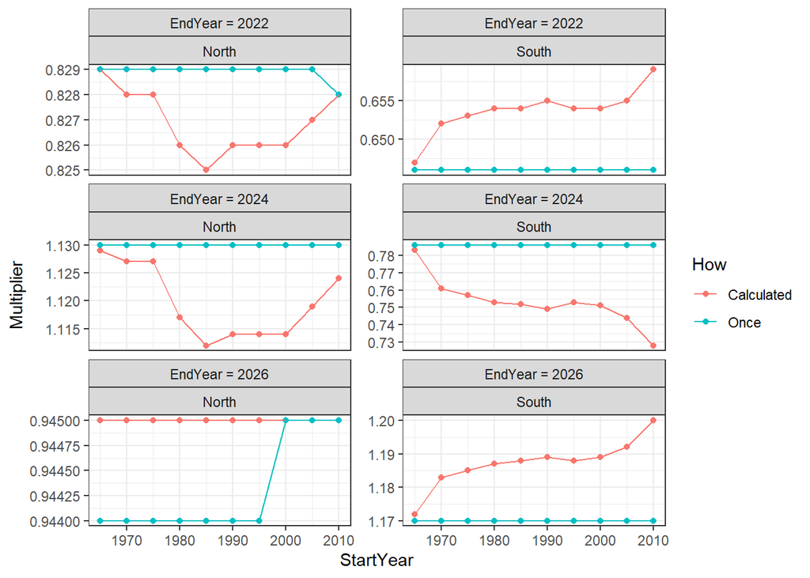

```r
print(tp1)
```

**Avg Plot**

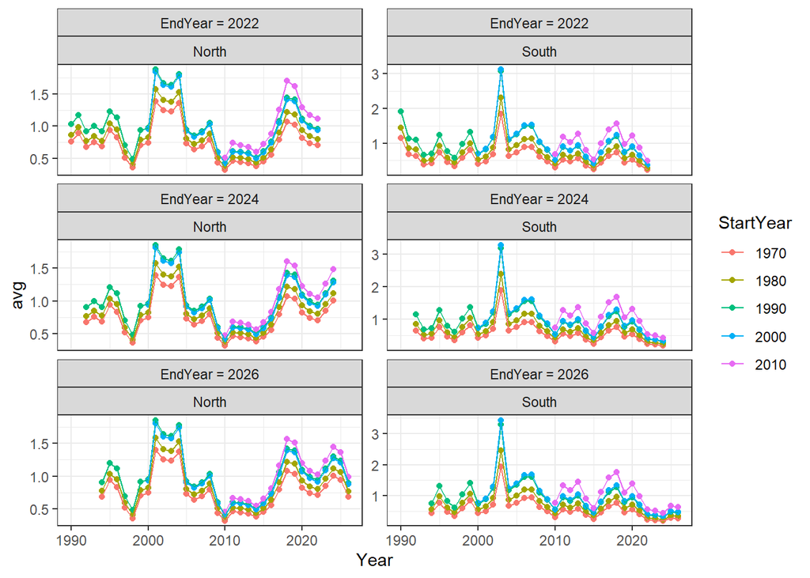

```r
print(tp2)
```

**Loess Plot**

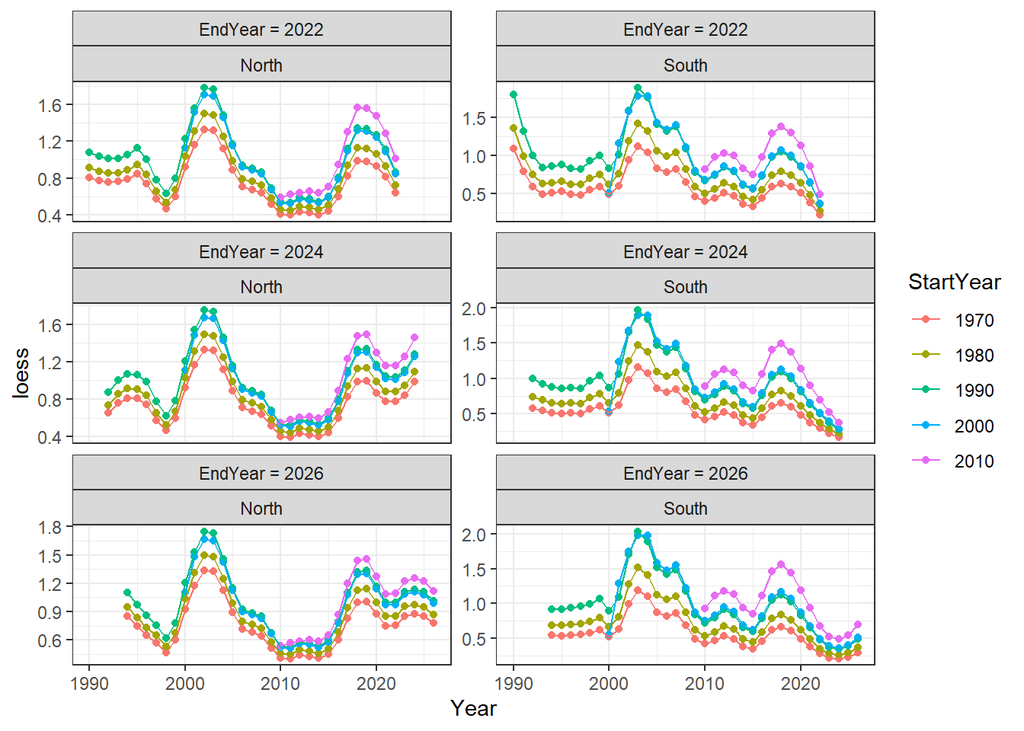

```r
print(tp3)
```

## Final Thoughts

- Be careful about year ranges when averaging. This can lead to differences when comparing to other results.
- Ismooth cannot use negative values because the linear regression used to estimate the multiplier is done on the log of the loess smoothed series through the avg values. This means you cannot standardize series using traditional Z-score. Dividing by the mean is not the only way to standardize a time series. You can do your own standardization and then go directly to Ismooth, if you so desire.
- There are no diagnostics for Ismooth, it is just a calculation. So there is no reason beyond precedent to use the current smoothing, time period for the linear regression, or lagging of the fall survey. Other approaches will give different multipliers, but there is not a diagnostic to judge which approach is best.
- Use of the fill test to examine whether to treat missing surveys as missing or fill them with a value require long time series. If you are only using a short time series, such as the Bigelow series or a short CPUE time series, then the fill test will not be useful.
- The `clean_stockeff_survey_data()` function works fine for stocks with just one season. Bluefish uses only the fall bottom trawl survey while spiny dogfish uses only the spring survey, and both ran through the function without problem (see code below).

```r
# check that single season stocks can run through clean_stockeff_survey_data() function

otherpath <- "other_StockEff_csvs"

# bluefish example (only fall survey)
mypurpose <- 10
myseasons <- c("FALL")
myindextype <- "Biomass (kg/tow)"

myfills_bluefish <- tibble(Year = c(2017, 2020),
                           Series = c("FALL", "FALL"),
                           Howfill = c("avg", "avg"))
myfilename <- "STOCKEFF_SV_168559_UNIT_NONE_strat_mean.csv"
mydata <- read.csv(file.path(otherpath, myfilename))
bluefish <- clean_stockeff_survey_data(mydata, mypurpose, myseasons, myindextype, myfills_bluefish)

# spiny dogfish example (only spring survey)
myseasons <- c("SPRING")
myfills_dogfish <- tibble(Year = c(2020, 2020, 2023, 2017),
                          Series = c("SPRING", "FALL", "SPRING", "FALL"),
                          Howfill = c("avg", "avg", "avg", "avg"))
myfilename <- "STOCKEFF_SV_160617_UNIT_FEMALE_strat_mean.csv"
mydata <- read.csv(file.path(otherpath, myfilename))
dogfish <- clean_stockeff_survey_data(mydata, mypurpose, myseasons, myindextype, myfills_dogfish)
```

## References

Legault, C. M., Wiedenmann, J., Deroba, J. J., Fay, G., Miller, T. J., Brooks, E. N., Bell, R. J., *et al.* 2023. Data-rich but model-resistant: An evaluation of data-limited methods to manage fisheries with failed age-based stock assessments. Canadian Journal of Fisheries and Aquatic Sciences, 80: 27–42. https://doi.org/10.1139/cjfas-2022-0045.

Miller, T. J., Richardson, D. E., Politis, P. J., Roebuck, C. D., Manderson, J. P., Martin, M. H., and Jones, A. W. 2023. Estimation of survey efficiency and biomass for commercially important species from industry-based paired gear experiments. Fisheries Research, 259: 106565. https://www.sciencedirect.com/science/article/pii/S0165783622003423.

NEFSC. TBD. Atlantic Cod Research Track Assessment Report. NOAA technical memorandum NMFS-NE. TBD.

NEFSC. 2013. 2013 monkfish operational assessment. Northeast Fisheries Science Center reference document 13-23. https://repository.library.noaa.gov/view/noaa/4560.

NEFSC. 2015. Operational Assessment of 20 Northeast Groundfish Stocks, updated through 2014. Northeast Fisheries Science Center reference document 15-24. https://repository.library.noaa.gov/view/noaa/5293.

NEFSC. 2017. Operational assessment of 19 northeast groundfish stocks, updated through 2016. Northeast Fisheries Science Center reference document 17-17. https://repository.library.noaa.gov/view/noaa/16091.

NEFSC. 2019. Stock Assessment Update of 14 Northeast Groundfish Stocks Through 2018. Northeast Fisheries Science Center reference document 22-06. https://repository.library.noaa.gov/view/noaa/39402.

NEFSC. 2020. Operational Assessment of the Black Sea Bass, Scup, Bluefish, and Monkfish Stocks, Updated Through 2018. Northeast Fisheries Science Center reference document 20-01. https://repository.library.noaa.gov/view/noaa/23006.

NEFSC. 2022. Management track assessments fall 2022. Northeast Fisheries Science Center technical memorandum 305. https://repository.library.noaa.gov/view/noaa/55264.

NEFSC. 2023. Report of the Index-Based Methods Working Group. NOAA technical memorandum NMFS-NE 285. https://repository.library.noaa.gov/view/noaa/49033.

Richards, R. A. 2016. 2016 monkfish operational assessment. Northeast Fisheries Science Center reference document 16-09. https://repository.library.noaa.gov/view/noaa/12008.

Wirgin, I., Maceda, L., Roy, N., Stabile, J., Curatolo-Wagemann, S., McClintock, T., Gerbino, K., *et al.* 2026. Microsatellite DNA analysis fails to detect genetic stock divisions along the entire coastwide distribution of American monkfish. Marine and Coastal Fisheries, 18: vtag004. https://doi.org/10.1093/mcfafs/vtag004.